# Yatin Kapur - Shopify Data Science Intern Challenge

```python
%matplotlib inline
%config InlineBackend.figure_format = 'retina'
import pandas as pd
import numpy as np
from collections import Counter
import matplotlib.pyplot as plt
import seaborn as sns

data = pd.read_csv('2019-challenge-data.csv')
data.head()
```

|  | order_id | shop_id | user_id | order_amount | total_items | payment_method | created_at |
| --- | --- | --- | --- | --- | --- | --- | --- |
| 0 | 1 | 53 | 746 | 224 | 2 | cash | 2017-03-13 12:36:56 |
| 1 | 2 | 92 | 925 | 90 | 1 | cash | 2017-03-03 17:38:52 |
| 2 | 3 | 44 | 861 | 144 | 1 | cash | 2017-03-14 4:23:56 |
| 3 | 4 | 18 | 935 | 156 | 1 | credit_card | 2017-03-26 12:43:37 |
| 4 | 5 | 18 | 883 | 156 | 1 | credit_card | 2017-03-01 4:35:11 |

It's said that the above AOV, which is the Average Order Value for the given data is \$3145.13. I need to first figure out how this value is being calculated:

```python
# total order amount divided by entries = aov calculated
aov = np.average(data['order_amount'])
print('AOV = ${:.2F}'.format(aov))
```

```
AOV = $3145.13
```

Evidently, this is happening by merely taking the average amount of all the order_amount entries. On first thought, I actually think this is the right way to evaluate the average order value. Because intuitively, it sounds like the average order value - taking the average of all the order amounts.

There are two possible sources of error in this way of calculating the average order value. First is the price of the sneakers, and the second is the amount of sneakers ordered per ordered. Let's study these two

I can look at the total order amount divided by total items bought - but that would give average amount of the items. But let's look at that to see if the sheer price of the sneakers is pulling this first AOV up.

```python
# total order amount divided by total items
total_items = np.sum(data['total_items'])
aiv = np.sum(data['order_amount'])/total_items # average item value
print('Average Item Amount = ${:.2F}'.format(aiv))
```

```
Average Item Amount = $357.92
```

This is a \$357.92 average amount of the ordered items - which is rather confusing. I don't know how this was helpful at all actually - since there is nothing to compare this with.

This has not exactly resulted in anything fruitful, I'm going to now look at any outliers that might be bringing this AOV higher than it needs to be. To go through 5000 entries is too laborious, so I'll group the orders by shop_id, and see which shops are selling unusually highly priced sneakers.

I will also take a look at how many items, on average, are purchased in a single order. We can then compare this with average order amount to see why there is a discrepancy.

```python
# total number of items purchased divided by total number of orders
print('Average number of items per order =  {:.2F}'.format(total_items/len(data)))
```

```
Average number of items per order =  8.79
```

Observe that the average number of items purchased per order is 8.79. This seems slightly off. To confirm that this is a strange number, I'll take a look at the median amount of items per order by extracting the five number summary - which will give us the 0th, 25th, 50th (median), 75th, and 100th quartile of this data.

```python
print('Five Number Summary for Items in an Order')
print('min = {}'.format(np.min(data['total_items'])))
print('25th quartile = {}'.format(np.percentile(data['total_items'], q=25)))
print('median = {}'.format(np.median(data['total_items'])))
print('75th quartile = {}'.format(np.percentile(data['total_items'], q=75)))
print('max = {}'.format(np.max(data['total_items'])))
```

```
Five Number Summary for Items in an Order
min = 1
25th quartile = 1.0
median = 2.0
75th quartile = 3.0
max = 2000
```

Notice that the median amount is only 2 items (sneakers) per order, and the 75th quartile is at 3 sneakers per order; however, the max amount is 2000 items per order! This paired with the result from the previous calculation tells us that there are a few outliers in the data (in terms of items per order) which are skewing this item per order data, and resultantly, probably the AOV as well. To demonstrate this further, let's look at a barplot of this item per order data.

```python
# make counter for the number of items in each order
bins = Counter()
for order in data['total_items']:
    bins[order] += 1

# sort data according to most common
item_data = np.transpose(bins.most_common())
bins_y = item_data[1]
x_ticks = item_data[0]
bins_x = np.arange(len(bins_y))
```

```
Text(0,0.5,'number of orders')
```

[figure not shown]

```python
plt.bar(bins_x, height=bins_y)
plt.xticks(bins_x, list(bins.keys()))
plt.xlabel('items in order')
plt.ylabel('number of orders')
```

At this point I will run the same exact steps on the average price. We have identified that there's a discrepancy in the number of items sold per order. Let's also try to identify if there is a discrepancy in the prices being charged, again, by looking at the five number summary.

```python
print('Five Number Summary for Price of Item per Order Amounts')
item_per_order_lst = data['order_amount'] / data['total_items']
print('min = ${:.2F}'.format(np.min(item_per_order_lst)))
print('25th quartile = ${:.2F}'.format(np.percentile(item_per_order_lst, q=25)))
print('median = ${:.2F}'.format(np.median(item_per_order_lst)))
print('75th quartile = ${:.2F}'.format(np.percentile(item_per_order_lst, q=75)))
print('max = ${:.2F}'.format(np.max(item_per_order_lst)))
```

```
Five Number Summary for Price of Item per Order Amounts
min = $90.00
25th quartile = $133.00
median = $153.00
75th quartile = $169.00
max = $25725.00
```

Recall that we saw a similar trend with items per order. The max is way too high, and is creating a discrepancy -- one seller is charging their clients too high of an amount.

The previous two results explain why the AOV is at an abnormal level, higher than it should be. And this is the problem with taking a raw average of the data. It rarely shows the entire picture. By using the five number summary and a visual representation we have been able to identify the source of error in this study.

At this point, we want to narrow down the shops which are selling these orders with such a high quantity, and also the shops which are charging an excessive amount of money

```python
# dataframe of orders sorted by shop_id with total order_amount and total_items
shop_data = data.groupby('shop_id').sum()[['order_amount', 'total_items']]
```

I will now look at the average amount of the items sold by each shop, and also the number of orders to that shop and enter those as new columns in the dataframe. The last type of data I want to look at is how many items per order each shop sells, because that would also help explain the high average value of orders - to find the one shop that just sells a lot more items on average resulting in their order price being higher (as noted earlier).

```python
# average price of items
shop_data['average_price'] = shop_data['order_amount']/shop_data['total_items']
# total orders for each shop
for i in range(1, 101):
    shop_data.loc[i, 'orders'] = np.int(len(data[data['shop_id'] == i]))
# average items per orderKapur
shop_data['items_per_order'] = shop_data['total_items']/shop_data['orders']
```

Okay, so the shop_id's show the average amount ordered for each item now, and I also know how many orders each shop received. I can now plot the average amount each shop chargers and look at any outliers.

```
Text(0.5,1,'Shops and Their Average Prices')
```

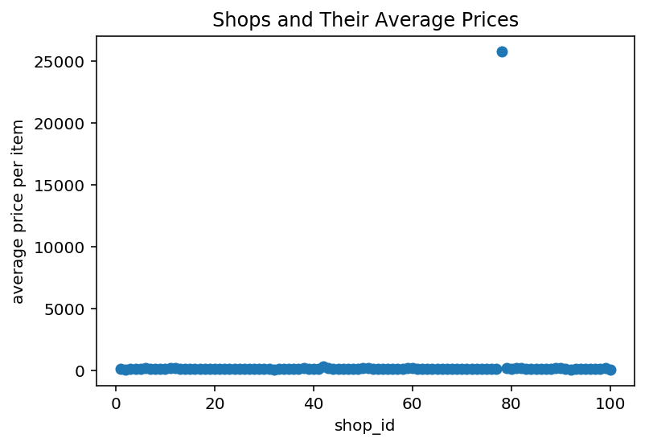

```python
plt.scatter(shop_data.index, shop_data.average_price)
plt.xlabel('shop_id')
plt.ylabel('average price per item')
plt.title('Shops and Their Average Prices')
```

```
Text(0.5,1,'Shops and Their Average Items Sold per Order')
```

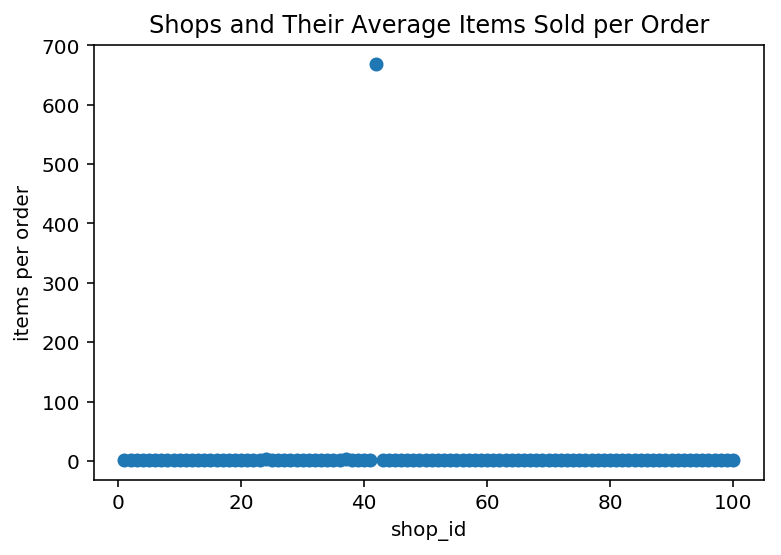

```python
plt.scatter(shop_data.index, shop_data.items_per_order)
plt.xlabel('shop_id')
plt.ylabel('items per order')
plt.title('Shops and Their Average Items Sold per Order')
```

1. take the median of all order_amount in the 'data' dataframe so that all data is accounted for, but outliers are largely ignored
2. exclude these shops from the dataset and then take AOV from a new dataframe

```python
# 1. median
median_approach = np.median(data['order_amount'])
print('Median of all Orders = ${:.2F}'.format(median_approach))
```

```
Median of all Orders = $284.00
```

```python
# 2. exclude shop_id which is selling at abnormally high prices
#   and abnormally high amounts of sneakesr
exclude_shop = [] # list of shop_id's to exclude
exclude_shop.append(shop_data[shop_data['average_price'] > 25000].index[0])
exclude_shop.append(shop_data[shop_data['items_per_order'] > 600].index[0])
new_data = data[~data['shop_id'].isin(exclude_shop)]
new_aov = np.average(new_data['order_amount'])
print('AOV = ${:.2F}'.format(new_aov))
```

```
AOV = $300.16
```

Since I have excluded the outliers now, it seems like a much better and reasonable figure for the AOV of sneakers. However, I've lost a bit of data by completely removing these outliers.

```python
print("There are only {:.0F}/{} orders now being looked at".format(len(new_data), 5000))
```

```
There are only 4903/5000 orders now being looked at
```

I realize now that it was so much easier if I calculated the median right away, but I'd probably have not known why that is had I not gone through the process to find the outliers.

#### Final Statement

Therefore, the metric to use is the median of the order_amount - which is a value of \$284.00